# Praktikum 5 Anreg

# Library

```r
library(readxl) # untuk membaca data
library(GGally) # untuk menghasilkan matriks hubungan antarpeubah
```

```r
library(corrplot) # untuk menghasilkan matriks korelasi
library(dplyr) # untuk manipulasi data
library(car) # untuk memeriksa multikolinearitas
```

# Data

```r
data <- read_xlsx("C:\\Users\\LENOVO\\Downloads\\Dataset Praktikum AnReg - Andhias (1).xlsx", sheet="Sheet1")
head(data) # menampilkan sekian data awal
```

```
## # A tibble: 6 × 13
##   Kabkot     Y    X1    X2    X3    X4    X5    X6    X7    X8    X9   X10   X11
##   <chr>  <dbl> <dbl> <dbl> <dbl> <dbl> <dbl> <dbl> <dbl> <dbl> <dbl> <dbl> <dbl>
## 1 Simeu… 10.1   2717  3298  2491 21111  5151  2937   677 13152   980 28874  6395
## 2 Aceh …  7.41  3645  3591  1605 19514  6951  2686  2536 17920  1223 26062  7635
## 3 Aceh … 10.2   2721  3256  1924 22123  6236  3507  1458 14771   988 26933  7236
## 4 Aceh … 11.6   4684  3537  1211 18672  5261  2987  1730 14685   930 24699  5847
## 5 Aceh …  7.96  3380  2898  1387 19817  4618  3121  1396 12709  1057 20405  7155
## 6 Aceh …  7.8   6090  4605  2650 20116  5438  3490  2802 17119  2242 24321 11590
```

```r
str(data) # menampilkan tipe data setiap peubah
```

```
## tibble [514 × 13] (S3: tbl_df/tbl/data.frame)
##  $ Kabkot: chr [1:514] "Simeulue" "Aceh Singkil" "Aceh Selatan" "Aceh Tenggara" ...
##  $ Y     : num [1:514] 10.11 7.41 10.2 11.57 7.96 ...
##  $ X1    : num [1:514] 2717 3645 2721 4684 3380 ...
##  $ X2    : num [1:514] 3298 3591 3256 3537 2898 ...
##  $ X3    : num [1:514] 2491 1605 1924 1211 1387 ...
##  $ X4    : num [1:514] 21111 19514 22123 18672 19817 ...
##  $ X5    : num [1:514] 5151 6951 6236 5261 4618 ...
##  $ X6    : num [1:514] 2937 2686 3507 2987 3121 ...
##  $ X7    : num [1:514] 677 2536 1458 1730 1396 ...
##  $ X8    : num [1:514] 13152 17920 14771 14685 12709 ...
##  $ X9    : num [1:514] 980 1223 988 930 1057 ...
##  $ X10   : num [1:514] 28874 26062 26933 24699 20405 ...
##  $ X11   : num [1:514] 6395 7635 7236 5847 7155 ...
```

```r
summary(data) # menampilkan ringkasan data
```

```
##     Kabkot                Y                X1              X2
##  Length:514         Min.   : 1.160   Min.   :  593   Min.   : 1459
##  Class :character   1st Qu.: 5.915   1st Qu.: 5212   1st Qu.: 3615
##  Mode  :character   Median : 8.375   Median : 7306   Median : 4314
##                     Mean   :10.749   Mean   : 8321   Mean   : 4443
##                     3rd Qu.:11.835   3rd Qu.:10088   3rd Qu.: 5165
##                     Max.   :59.170   Max.   :41711   Max.   :17173
##        X3              X4              X5              X6              X7
##  Min.   :  265   Min.   :   25   Min.   : 2412   Min.   : 1288   Min.   : 337
##  1st Qu.: 2710   1st Qu.:11584   1st Qu.: 4169   1st Qu.: 2840   1st Qu.:2182
##  Median : 3847   Median :17083   Median : 4831   Median : 3532   Median :2810
##  Mean   : 4131   Mean   :16918   Mean   : 5067   Mean   : 3688   Mean   :2945
##  3rd Qu.: 5212   3rd Qu.:21292   3rd Qu.: 5643   3rd Qu.: 4257   3rd Qu.:3767
##  Max.   :11056   Max.   :55341   Max.   :16710   Max.   :17418   Max.   :6375
##        X8              X9              X10             X11
##  Min.   : 5778   Min.   :   238   Min.   : 6755   Min.   : 1057
##  1st Qu.:11306   1st Qu.:  1288   1st Qu.:19428   1st Qu.: 7552
##  Median :13898   Median :  1737   Median :21764   Median : 9252
##  Mean   :14895   Mean   :  3613   Mean   :22469   Mean   : 9655
##  3rd Qu.:17060   3rd Qu.:  2324   3rd Qu.:24853   3rd Qu.:11351
##  Max.   :81168   Max.   :120513   Max.   :46136   Max.   :23795
```

Data yang digunakan adalah data dari 514 Kabupaten/Kota di Indonesia pada Tahun 2025 dengan 1 peubah respon yaitu Prevalensi Ketidakcukupan Konsumsi Pangan dan 11 peubah penjelas yang terdiri dari 11 peubah kuantitatif. Peubah tersebut adalah Rata-rata Pengeluaran Perkapita Seminggu Menurut Kelompok Daging, Telur, Susu, Ikan, Minyak dan Kelapa, Bumbu-bumbuan, Kacang-kacangan, Sayur-sayuran, Umbi-umbian, Padi-padian, dan Buah-buahan.

# Eksplorasi data

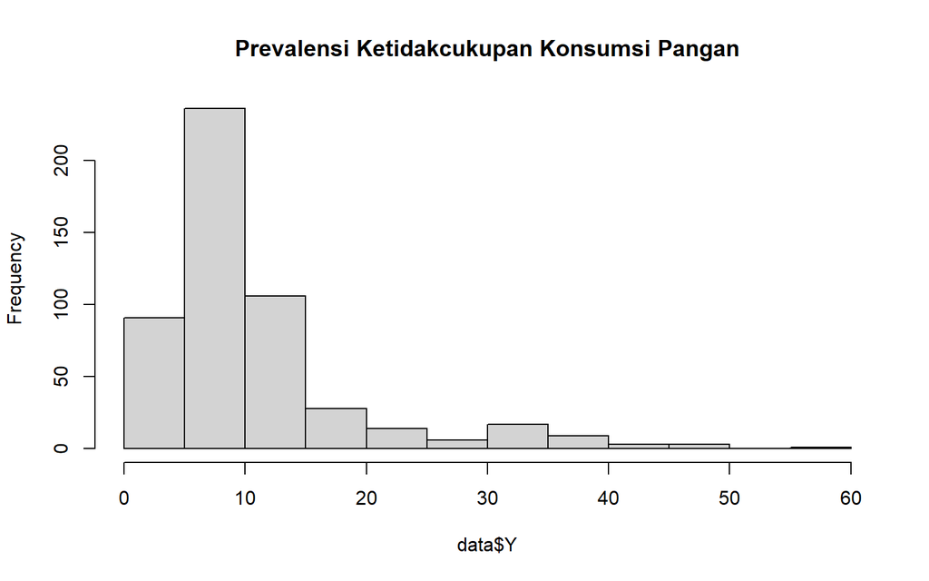

```r
hist(data$Y, main = "Prevalensi Ketidakcukupan Konsumsi Pangan")
```

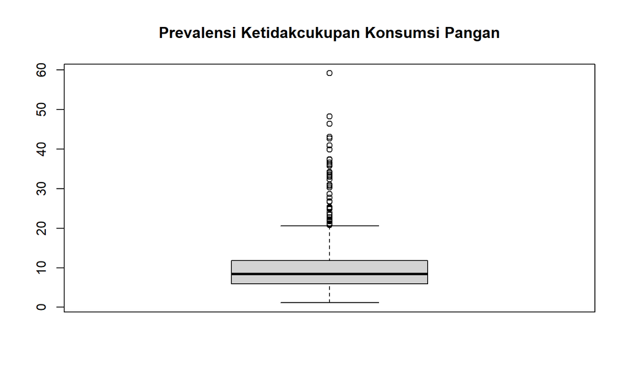

```r
boxplot(data$Y, main = "Prevalensi Ketidakcukupan Konsumsi Pangan")
```

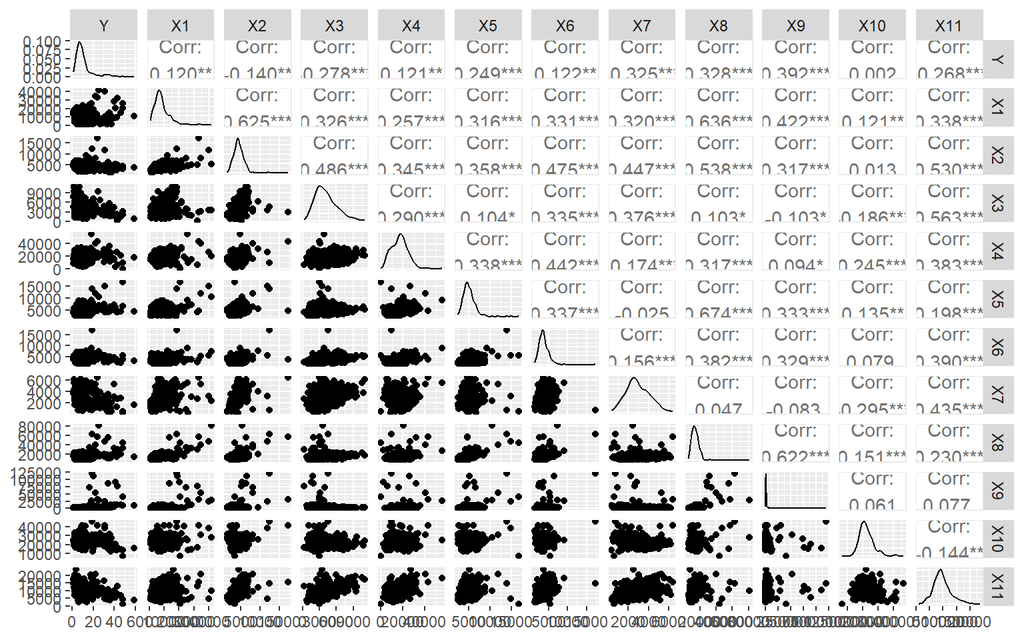

```r
library(GGally)

ggpairs(data[, c("Y", "X1", "X2", "X3", "X4", "X5",
                 "X6", "X7", "X8", "X9", "X10", "X11")])
```

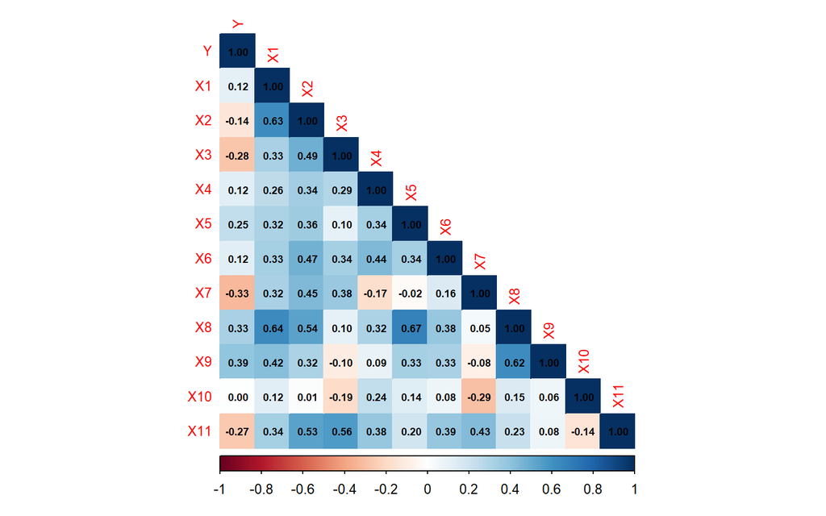

```r
cor_matrix <- cor(data[, c("Y", "X1", "X2", "X3", "X4", "X5",
                 "X6", "X7", "X8", "X9", "X10", "X11")])
corrplot(cor_matrix,
         method = "color",
         type = "lower",
         tl.cex = 0.8,
         addCoef.col = "black",
         number.cex = 0.6,
         cl.lim = c(-1, 1))
```

Hasil matriks scatter plot dan korelasi menunjukkan bahwa peubah respon memiliki hubungan positif dengan X1, X4, X5, X6, X8, X9, dan X10, serta hubungan negatif dengan X2, X3, X7, dan X11.

Selain itu, terdapat banyak korelasi tinggi antar peubah penjelas. Beberapa di antaranya adalah: 1. X2 dan X1 memiliki korelasi 0.63. 2. X8 dan X1 memiliki korelasi 0.64. 3. X8 dan X5 memiliki korelasi 0.67.

Korelasi yang tinggi ini mengindikasikan adanya potensi multikolinearitas, yang dapat mempengaruhi keakuratan model yang akan dibentuk.